# Lab 8: Clustering and SVM

PSTAT 131/231

## Introduction

In this lab, we’ll explore doing some unsupervised learning with *k*-means clustering (in which we’ll tune *k*, the number of clusters) and how to use and tune support vector machines with both linear and radial kernels. We’ll use the Palmer penguins data set for both of these example sections.

### Loading Packages

```r
library(tidymodels)
library(ISLR)
library(ISLR2)
library(tidyverse)
library(glmnet)
library(modeldata)
library(kernlab)
library(tidyclust)
library(corrplot)
library(palmerpenguins) # for the penguins data
tidymodels_prefer()
```

### Data

Here we load in the data as in Lab 7, then remove any observations with missingness:

```r
penguins <- as_tibble(palmerpenguins::penguins) %>%
  drop_na()
```

Then we split the data, stratifying by `species`, and use 5-fold cross-validation:

```r
set.seed(3435)
penguin_split <- initial_split(penguins, strata = "species")

penguin_train <- training(penguin_split)
penguin_test <- testing(penguin_split)

penguin_folds <- vfold_cv(penguin_train, v = 5, strata = "species")

penguin_pal <- c("#fb7504", "#c65ccc", "#047374")
```

## *k*-means Clustering

Note: You’ll likely need to install the package `tidyclust` to run the code in this section.

To simplify the models we’ll be fitting, we’re just going to use two features, `body_mass_g` (or body mass in grams) and `bill_length_mm` (or bill length in millimeters), to cluster the penguins. Remember that *k*-means clustering is a method of **unsupervised** learning, meaning it is used when we don’t have measurements of an outcome variable. That isn’t the case here with species, but for the purpose of the example, we will pretend not to know the species of each penguin.

We can view a plot of our two predictors by `species` first to verify that this is a good situation for clustering. It clearly is; there are three fairly distinct clusters of points, one per species, although with a little bit of overlap.

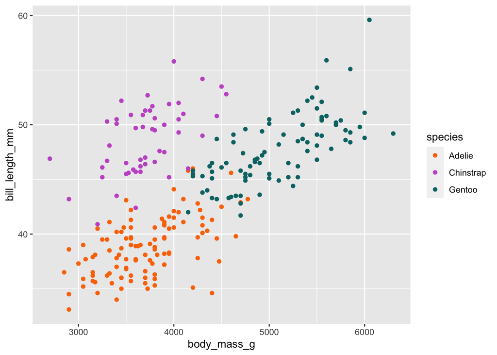

```r
ggplot(penguin_train, aes(body_mass_g, bill_length_mm, color = species)) +
  geom_point() +
  scale_color_manual(values = penguin_pal)
```

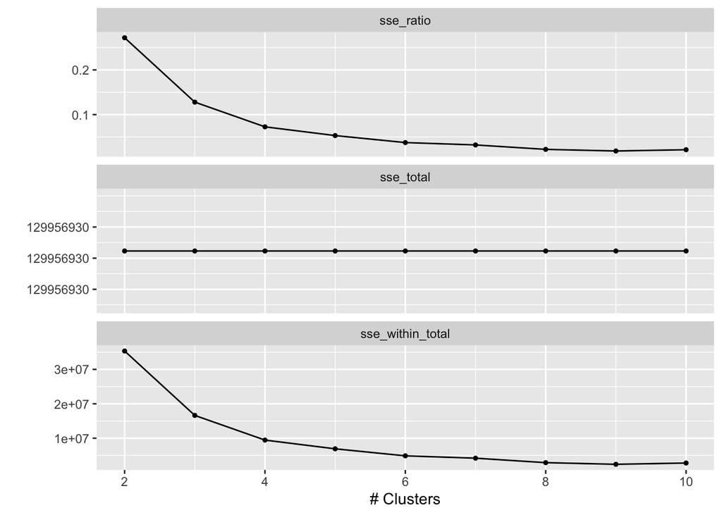

```r
kmeans_spec <- k_means(num_clusters = tune())

kmeans_rec <- recipe(~ body_mass_g + bill_length_mm, data = penguin_train)

kmeans_wflow <- workflow(kmeans_rec, kmeans_spec)

clust_num_grid <- grid_regular(num_clusters(),
                               levels = 10)

kmeans_res <- tune_cluster(kmeans_wflow,
                            penguin_folds, clust_num_grid,
                            metrics = cluster_metric_set(sse_within_total, sse_total, sse_ratio)
)
kmeans_res %>% autoplot()
```

We can specifically focus on the plot of `sse_ratio` by the number of clusters and make it larger so it’s easier to assess:

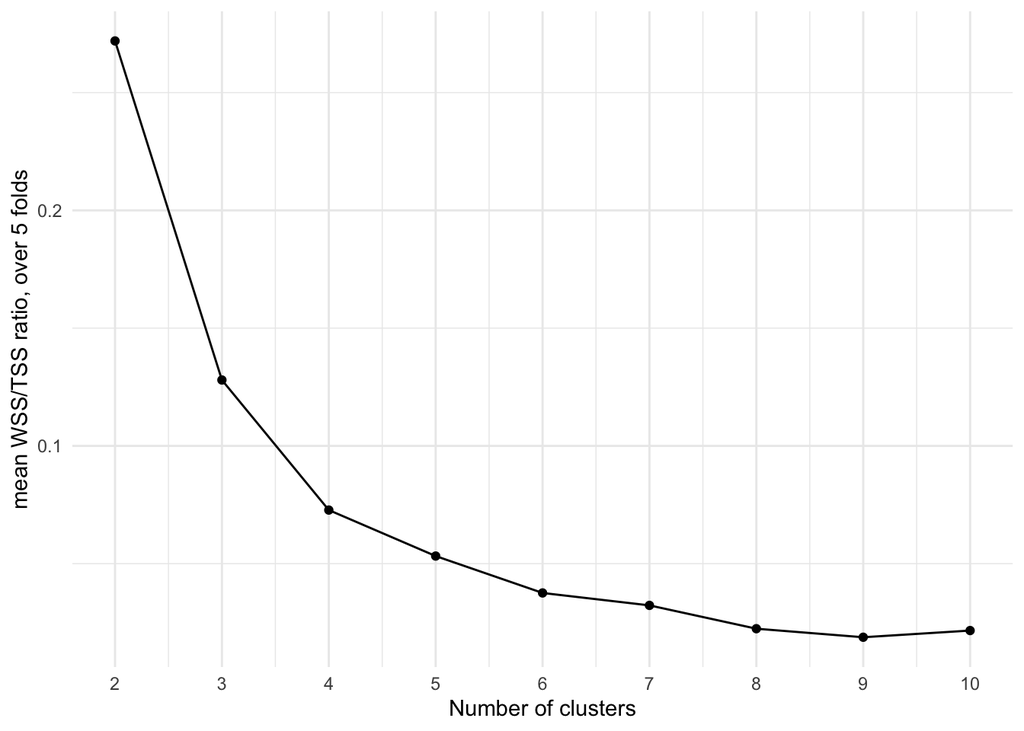

```r
kmeans_res %>%
  collect_metrics() %>%
  filter(.metric == "sse_ratio") %>%
  ggplot(aes(x = num_clusters, y = mean)) +
  geom_point() +
  geom_line() +
  theme_minimal() +
  ylab("mean WSS/TSS ratio, over 5 folds") +
  xlab("Number of clusters") +
  scale_x_continuous(breaks = 1:10)
```

You can imagine that we might pick a slightly different number of clusters if we didn’t already know that there are three species of penguins in the data, but this plot, also known as a scree plot, would likely lead us to choose anywhere from 2 to 4 clusters.

## Support Vector Machines

We’ll demonstrate how to fit two types of support vector machines, one with a linear kernel and one with a radial kernel. We’ll continue to use the Palmer penguins data for these examples, but this time we’ll attempt to classify penguins by sex (coded as `male` or `female`) rather than species. Note that support vector machines all support multiclass classification problems as well, but it’s easier to visualize them with two-class problems.

We’ll use only two features/predictors here as well so we can visualize things more easily; let’s use penguins’ body mass in grams and bill length in millimeters. We can look at a plot of the predictors, with observations colored by level of the outcome:

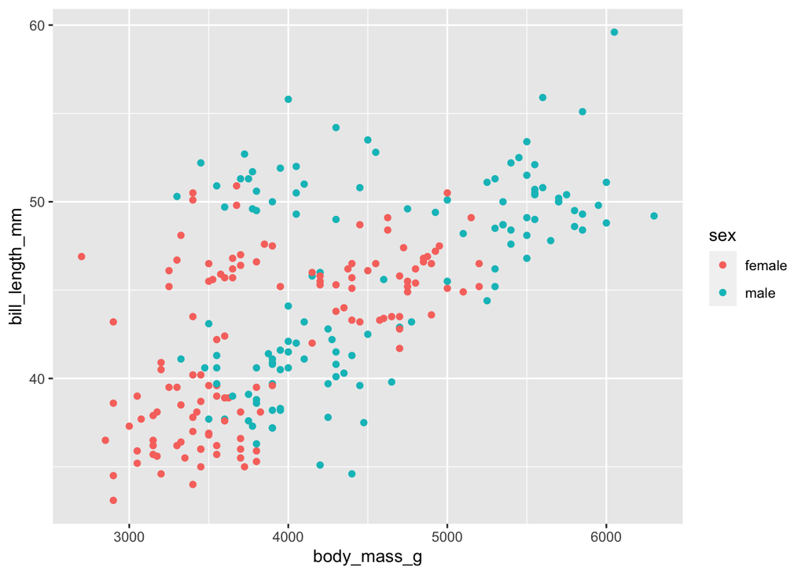

```r
ggplot(penguin_train, aes(body_mass_g, bill_length_mm, color = sex)) +
  geom_point()
```

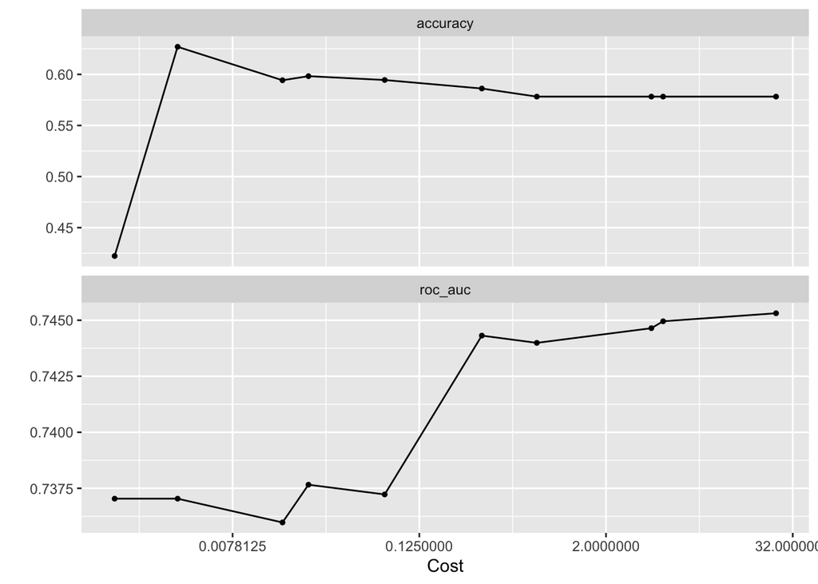

```r
svm_rec <- recipe(sex ~ bill_length_mm + body_mass_g,
                         data = penguin_train) %>%
  step_normalize(all_predictors())

svm_linear_spec <- svm_poly(degree = 1, cost = tune()) %>%
  set_mode("classification") %>%
  set_engine("kernlab")

svm_linear_wkflow <- workflow() %>%
  add_recipe(svm_rec) %>%
  add_model(svm_linear_spec)

svm_linear_grid <- grid_regular(cost(), degree(), levels = 5)

svm_linear_res <- tune_grid(svm_linear_wkflow,
                            penguin_folds, svm_linear_grid)

svm_linear_res %>% autoplot()
```

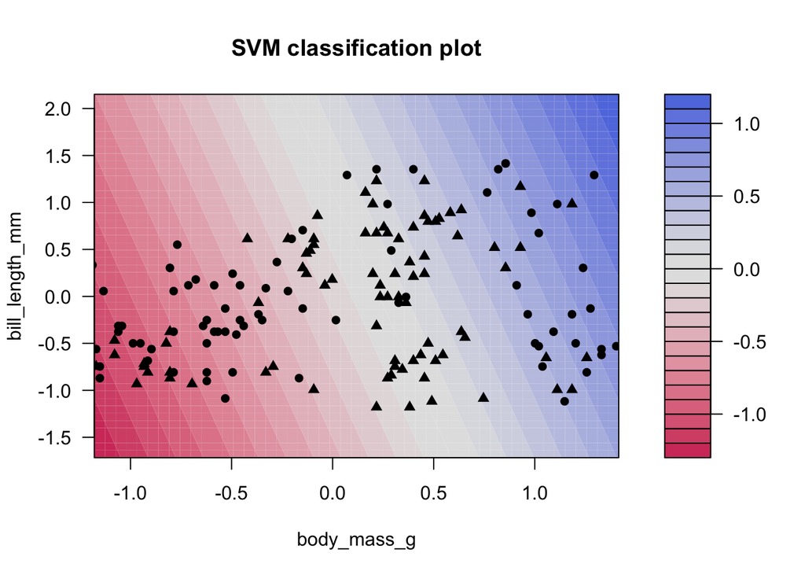

```r
svm_best_linear <- select_best(svm_linear_res)

svm_final_linear_fit <- finalize_workflow(svm_linear_wkflow, svm_best_linear) %>%
  fit(penguin_train)

svm_final_linear_fit %>%
  extract_fit_engine() %>%
  plot()
```

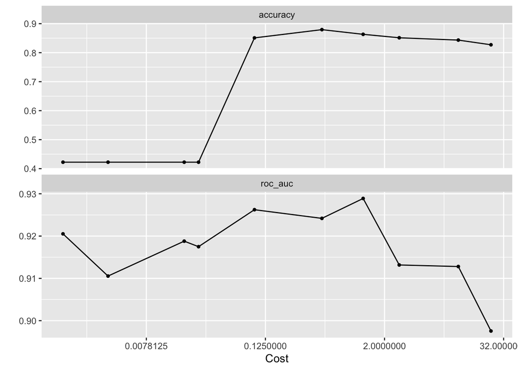

```r
svm_rbf_spec <- svm_rbf(cost = tune()) %>%
  set_mode("classification") %>%
  set_engine("kernlab")
svm_rbf_wkflow <- workflow() %>%
  add_recipe(svm_rec) %>%
  add_model(svm_rbf_spec)

svm_rbf_grid <- grid_regular(cost(), levels = 5)

svm_rbf_res <- tune_grid(svm_rbf_wkflow,
                            penguin_folds, svm_rbf_grid)

svm_rbf_res %>% autoplot()
```

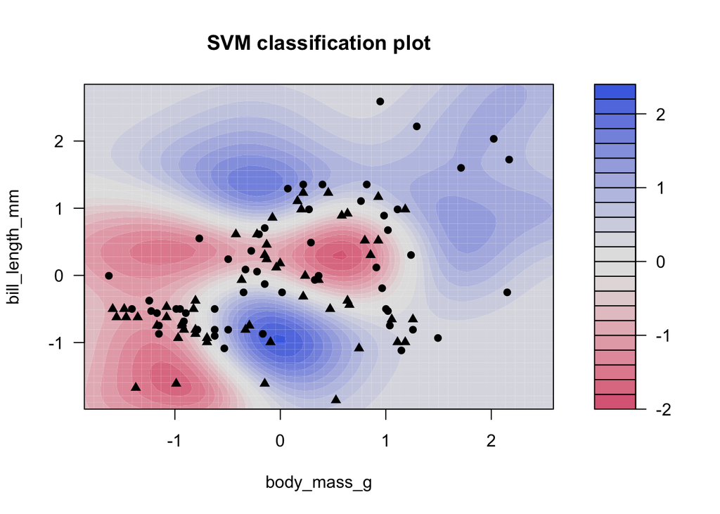

```r
svm_best_radial <- select_best(svm_rbf_res)

svm_final_radial_fit <- finalize_workflow(svm_rbf_wkflow, svm_best_radial) %>%
  fit(penguin_train)

svm_final_radial_fit %>%
  extract_fit_engine() %>%
  plot()
```

Now let’s look at the performance of this model – which is the best of our two SVM kernels – on the testing data:

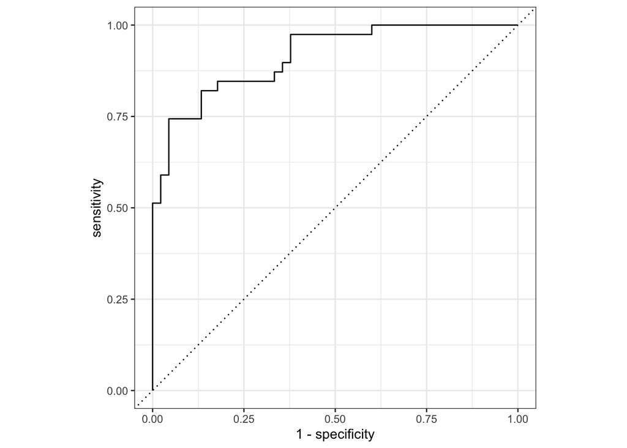

```r
augment(svm_final_radial_fit, penguin_test) %>%
  select(sex, starts_with(".pred")) %>%
  roc_curve(sex, .pred_female) %>%
  autoplot()
```

```r
augment(svm_final_radial_fit, penguin_test) %>%
  select(sex, starts_with(".pred")) %>%
  roc_auc(sex, .pred_female)
```

```
## # A tibble: 1 × 3
##   .metric .estimator .estimate
##   <chr>   <chr>          <dbl>
## 1 roc_auc binary         0.915
```

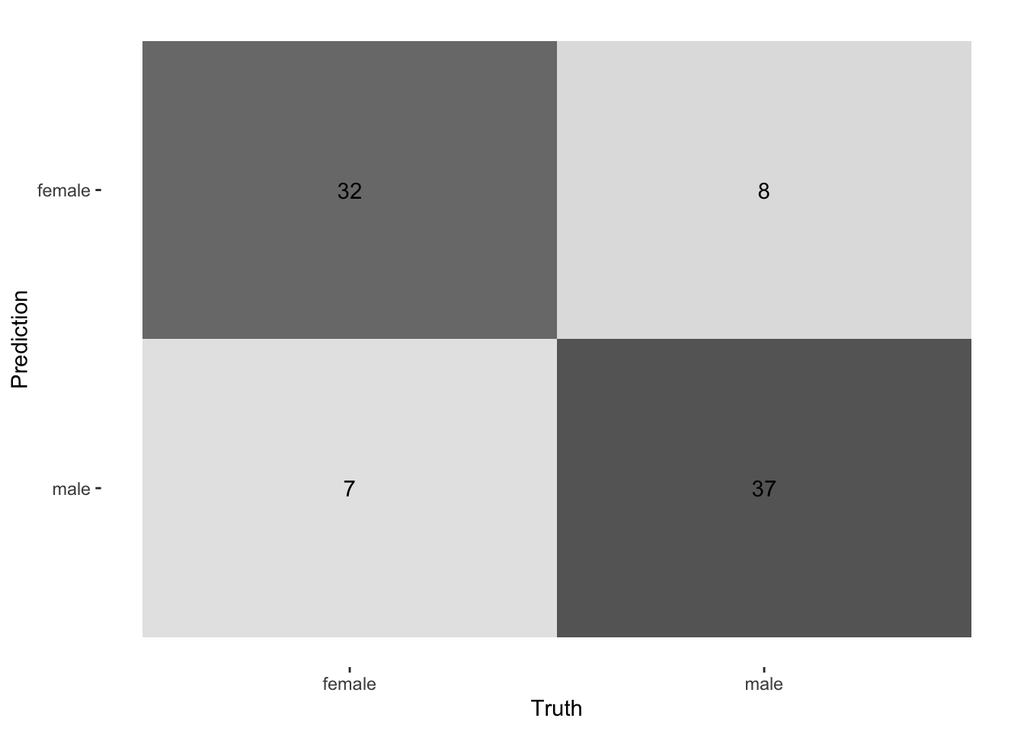

```r
augment(svm_final_radial_fit, penguin_test) %>%
  select(sex, starts_with(".pred")) %>%
  conf_mat(sex, .pred_class) %>%
  autoplot(type = "heatmap")
```

## Resources

The free book [Tidy Modeling with R](https://www.tmwr.org/) is strongly recommended.